# Regression Exercise

# 1 Data Understanding

You will work on airfoil self noise prediction. Data comes from NASA airfoil testing. Airfoil blade sections were tested with regards to sound emission.

These are the independent variables:

- Frequency, in Hertzs.
- Angle of attack, in degrees.
- Chord length, in meters.
- Free-stream velocity, in meters per second.
- Suction side displacement thickness, in meters.

The target variable is

- Scaled sound pressure level, in decibels.

```r
suppressPackageStartupMessages(library(dplyr))
suppressPackageStartupMessages(library(ggplot2))
suppressPackageStartupMessages(library(corrplot))
suppressPackageStartupMessages(library(keras))
suppressPackageStartupMessages(library(caret))

source('./train_val_test_split.R')
```

# 2 Data Preparation

```r
# if file does not exist, download it first
file_path <- "./data/airfoil_noise.txt"
if (!file.exists(file_path)) {
  dir.create("./data")
  url <- "https://archive.ics.uci.edu/ml/machine-learning-databases/00291/airfoil_self_noise.dat"
  download.file(url = url,
                destfile = file_path)
}
```

Import the data and assign it to object *airfoil_noise*:

```r
airfoil_noise <- read.delim('./data/airfoil_noise.txt', header=F)
```

Assign the right column names. Please use these names:

frequency, aoa, chord_length, free_stream_vel, ss_displacement_thickness, spl)

```r
column_names <- c('frequency', 'aoa', 'chord_length', 'free_stream_vel', 'ss_displacement_thickness', 'spl')
colnames(airfoil_noise) <- column_names
airfoil_noise %>% head()
```

```
##   frequency aoa chord_length free_stream_vel ss_displacement_thickness
## 1       800   0       0.3048            71.3                0.00266337
## 2      1000   0       0.3048            71.3                0.00266337
## 3      1250   0       0.3048            71.3                0.00266337
## 4      1600   0       0.3048            71.3                0.00266337
## 5      2000   0       0.3048            71.3                0.00266337
## 6      2500   0       0.3048            71.3                0.00266337
##       spl
## 1 126.201
## 2 125.201
## 3 125.951
## 4 127.591
## 5 127.461
## 6 125.571
```

## 2.1 Exploratory data analysis

Create a correlation plot for the data to understand which variables are most valuable to predict sound pressure level.

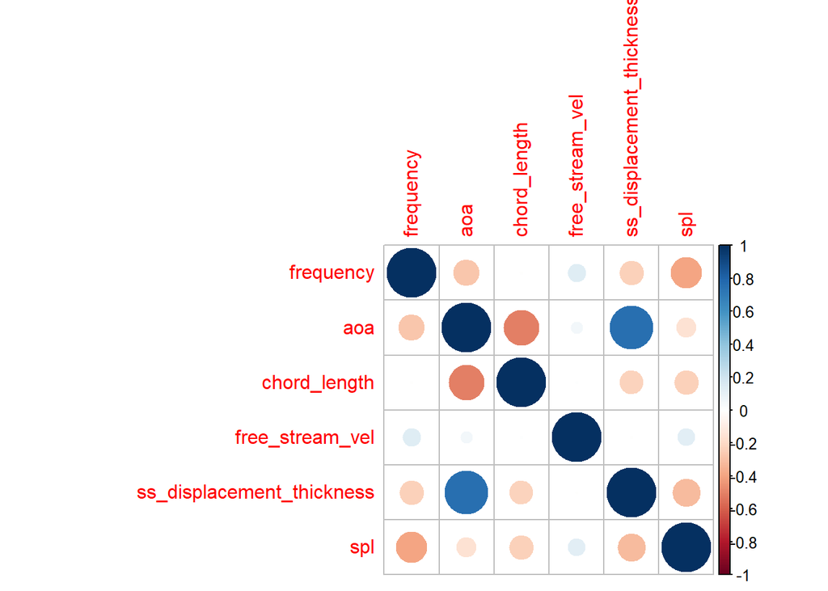

```r
airfoil_noise_scaled <- airfoil_noise %>%
  scale()%>%
  as_tibble()

corr_an <- cor(airfoil_noise_scaled)
corrplot(corr_an, method='circle')
```

Which two variables correlate most to target variable?

```r
# The frequency and the suction side displacement thickness (ss_displacement_thickness).
```